# 臺灣各縣市社經條件與勞動市場脆弱度分析

曾怡雅 Yi Ya Tseng

2025/12

## 一、研究背景與資料說明

本專案以臺灣 19 縣市(不包含離島)為分析單位，整合 2019–2024 年主計總處與勞動部統計資料， 探討哪些社經因素影響縣市薪資水準，並比較多種機器學習方法的預測表現。

**核心問題：**

1. 哪些社經因素最能解釋縣市間的薪資差異？
2. 臺灣各縣市在勞動條件上呈現哪些群聚型態？
3. 哪種模型最能預測縣市平均薪資？

```r
df      <- read.csv("data/processed/taiwan_clean.csv",  encoding = "UTF-8", stringsAsFactors = FALSE)
df_2024 <- read.csv("data/processed/taiwan_2024.csv",   encoding = "UTF-8", stringsAsFactors = FALSE)

df      <- df      %>% filter(region != "離島")
df_2024 <- df_2024 %>% filter(region != "離島")

cat("觀測數：", nrow(df), "| 縣市數：", n_distinct(df$county), "| 年份：2019–2024\n")
```

```
## 觀測數： 114 | 縣市數： 19 | 年份：2019–2024
```

**變數說明：**

| 變數 | 說明 | 單位 |
| --- | --- | --- |
| `wage` | 月薪中位數（年薪÷12） | 萬元 |
| `unemp_rate` | 失業率 | % |
| `lfpr` | 勞動力參與率 | % |
| `college_pct` | 大學以上學歷人口比例 | % |
| `aging_idx` | 老化指數 | 65歲+/15歲以下×100 |
| `log_density` | 人口密度（對數） | ln(人/km²) |
| `industry_pct` | 工業就業結構比例（含製造、營造等） | % |

## 二、探索性資料分析（EDA）

### 2.1 各縣市薪資分布

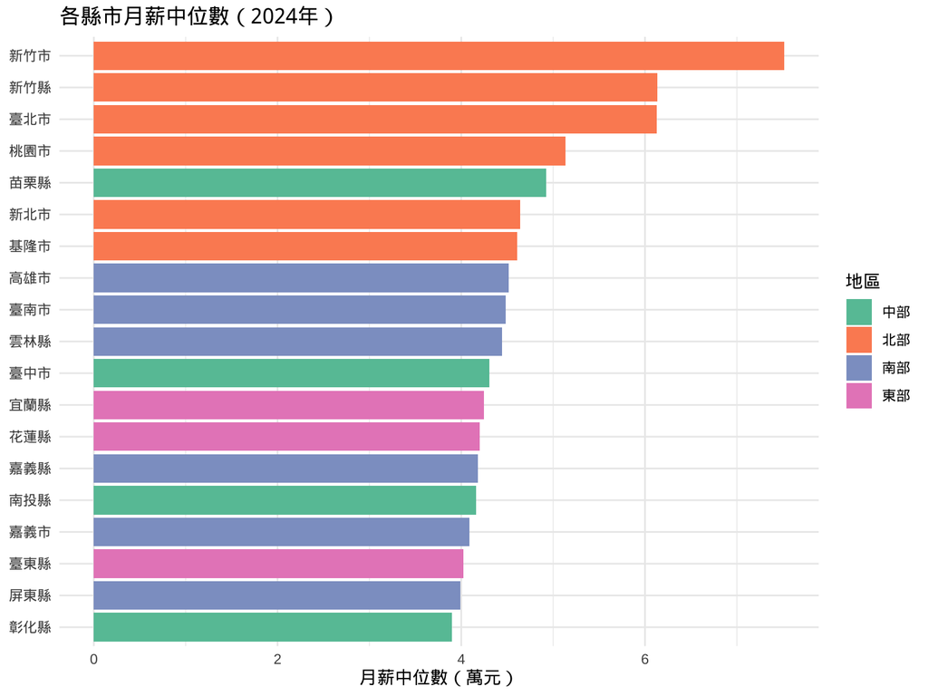

```r
df_2024 %>%
  filter(!is.na(wage)) %>%
  arrange(desc(wage)) %>%
  ggplot(aes(x = reorder(county, wage), y = wage, fill = region)) +
  geom_col() +
  coord_flip() +
  scale_fill_brewer(palette = "Set2") +
  labs(title = "各縣市月薪中位數（2024年）",
       x = NULL, y = "月薪中位數（萬元）", fill = "地區") +
  theme_minimal(base_size = 11)
```

### 2.2 薪資趨勢（2019–2024）

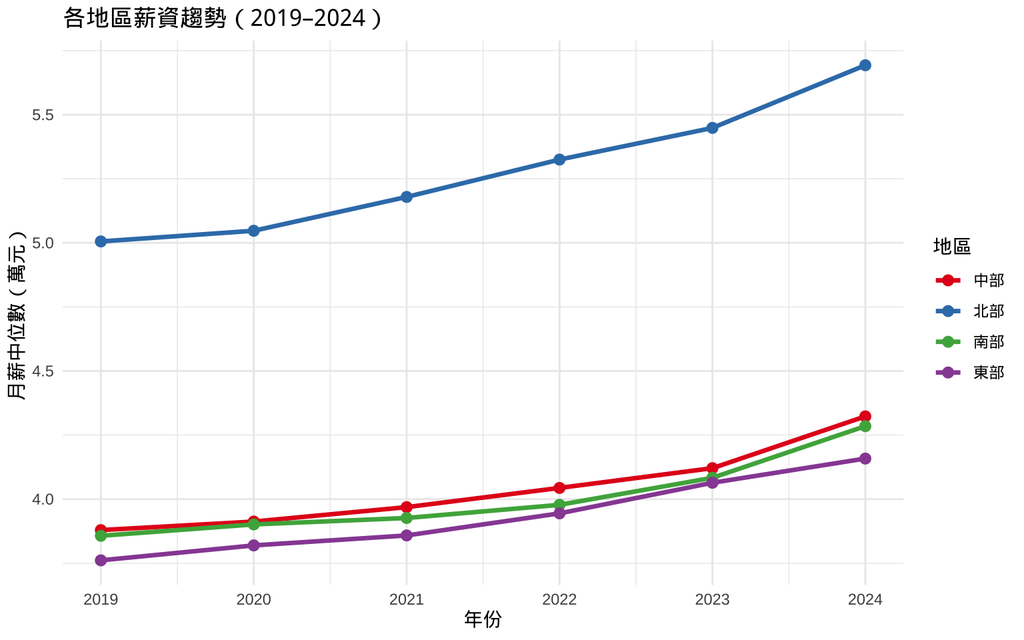

```r
df %>%
  group_by(year, region) %>%
  summarise(mean_wage = mean(wage), .groups = "drop") %>%
  ggplot(aes(x = year, y = mean_wage, color = region, group = region)) +
  geom_line(linewidth = 1.2) + geom_point(size = 2.5) +
  scale_color_brewer(palette = "Set1") +
  labs(title = "各地區薪資趨勢（2019–2024）",
       x = "年份", y = "月薪中位數（萬元）", color = "地區") +
  theme_minimal()
```